# Register data with provided parameters

This article will show users how to register data using some pre-defined shift and stretch parameters. This demo will use one of the genes from the sample data provided by the package. Users can check whether their sample data can be registered using the manually specified shift and stretch values.

## Load sample data

`greatR` package provides an example of data frame containing two different species *A. thaliana* and *B. rapa* with two and three different replicates, respectively. This data frame can be read as follows:

```r
# Load the package
library(greatR)
library(data.table)
```

```r
# Load a data frame from the sample data
b_rapa_data <- system.file("extdata/brapa_arabidopsis_all_replicates.csv", package = "greatR") |>
  data.table::fread()
```

## Registering single gene

Here, we will only use a single gene with `gene_id = "BRAA03G023790.3C"` from the sample data.

```r
gene_BRAA03G023790.3C_data <- b_rapa_data[gene_id == "BRAA03G023790.3C"]
```

Before registering, we can use the helper function `get_approximate_stretch()` to approximate the stretch factor between our sample datasets as shown in the figure below.

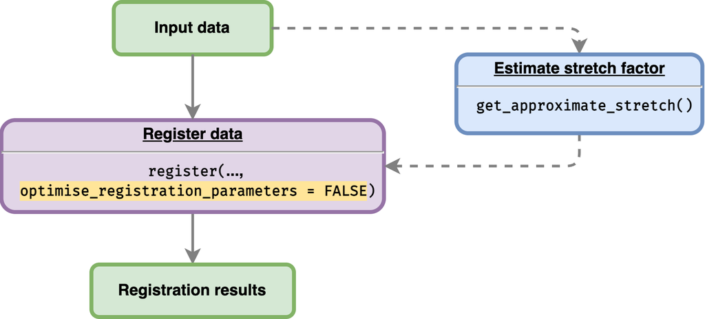

```r
get_approximate_stretch(
  gene_BRAA03G023790.3C_data,
  reference = "Ro18",
  query = "Col0"
)
```

```
#> [1] 2.666667
```

We can now use the estimated stretch calculated above in the registration process below. Users need to set `optimise_registration_parameters = FALSE` to disable the automated optimisation process.

```r
registration_results <- register(
  gene_BRAA03G023790.3C_data,
  reference = "Ro18",
  query = "Col0",
  scaling_method = "z-score",
  stretches = 2.6,
  shifts = 4,
  optimise_registration_parameters = FALSE
)
```

```
#> ── Validating input data ───────────────────────────────────────────────────────
#> ℹ Will process 1 gene.
#> ℹ Using estimated standard deviation, as no `exp_sd` was provided.
#>
#> ── Starting manual registration ────────────────────────────────────────────────
#> ✔ Applying registration for genes (1/1) [34ms]
```

To check whether the gene is registered or not, we can get the summary results by accessing the `model_comparison` table from the registration result.

```r
registration_results$model_comparison |>
  knitr::kable()
```

| gene_id | stretch | shift | BIC_diff | registered |
| --- | --- | --- | --- | --- |
| BRAA03G023790.3C | 2.6 | 4 | -5.034115 | TRUE |

As we can see, using the given stretch and shift parameter above, the *B. rapa* gene *BRAA03G023790.3C* can be registered.

## Registering multiple gene with different pre-defined registration parameters

Users can also register multiple different genes using their pre-defined parameters. Similar to registration process above, users need to set `optimise_registration_parameters = FALSE` to disable the automated optimisation process.

```r
registration_results <- register(
  b_rapa_data,
  reference = "Ro18",
  query = "Col0",
  scaling_method = "z-score",
  stretches = seq(1, 3, 0.1),
  shifts = seq(0, 4, 0.1),
  optimise_registration_parameters = FALSE
)
```

```
#> ── Validating input data ───────────────────────────────────────────────────────
#> ℹ Will process 10 genes.
#> ℹ Using estimated standard deviation, as no `exp_sd` was provided.
#>
#> ── Starting manual registration ────────────────────────────────────────────────
#> ✔ Applying registration for genes (10/10) [15.5s]
```

Similar to the previous registration process, users can analyse further the registration result by following the [visualising results](https://ruthkr.github.io/greatR/articles/visualise-results.html) vignette.